# US Bike Share Project

- How does ridership differ by month or season? Which month / season has the highest ridership? Does the ratio of Subscriber trips to Customer trips change depending on the month or season?
- Is the pattern of ridership different on the weekends versus weekdays? On what days are Subscribers most likely to use the system? What about Customers? Does the average duration of rides change depending on the day of the week?
- During what time of day is the system used the most? Is there a difference in usage patterns for Subscribers and Customers?

Let's Continue the investigation by exploring another question that could be answered by the data available.

```
No.of rides in the Month of Jan: 1901
No.of rides in the Month of Feb: 2394
No.of rides in the Month of Mar: 3719
No.of rides in the Month of Apr: 4567
No.of rides in the Month of May: 7211
No.of rides in the Month of Jun: 9794
No.of rides in the Month of Jul: 10286
No.of rides in the Month of Aug: 9810
No.of rides in the Month of Sep: 8700
No.of rides in the Month of Oct: 7160
No.of rides in the Month of Nov: 4811
No.of rides in the Month of Dec: 1778
```

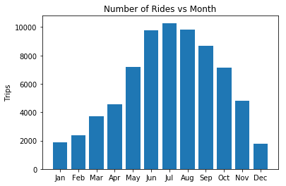

```
No.of rides in the Month of Jan-Mar: 8014
No.of rides in the Month of Apr-Jun: 21572
No.of rides in the Month of Jul-Sep: 28796
No.of rides in the Month of Oct-Dec: 13749
```

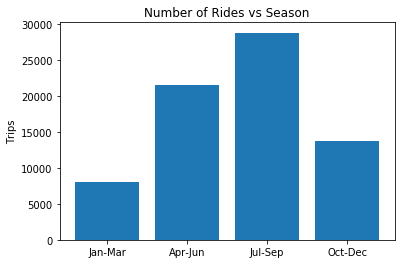

```python
def ride_month(filename):
    month_list = []
    month_dict = {}
    data_files_c = './data/Chicago-Divvy-2016.csv'
    with open(data_files_c,'r') as f:
        trip_reader = csv.DictReader(f)

        for row in trip_reader:
            t = row['starttime']
            mymonth = datetime.strptime(t,'%m/%d/%Y %H:%M')
            month = mymonth.strftime('%b')
            month_list.append(month)

        my_dict = {i:month_list.count(i) for i in month_list}
        #print(my_dict)
    return my_dict

def month_list(filename):
    my_months = ride_month(filename)
    #print(my_months)
    months = {}
    months['Jan'] = my_months.get('Jan')
    months['Feb'] = my_months.get('Feb')
    months['Mar'] = my_months.get('Mar')
    months['Apr'] = my_months.get('Apr')
    months['May'] = my_months.get('May')
    months['Jun'] = my_months.get('Jun')
    months['Jul'] = my_months.get('Jul')
    months['Aug'] = my_months.get('Aug')
    months['Sep'] = my_months.get('Sep')
    months['Oct'] = my_months.get('Oct')
    months['Nov'] = my_months.get('Nov')
    months['Dec'] = my_months.get('Dec')

    print('No.of rides in the Month of Jan: {}'.format((my_months.get('Jan','No rides recorded'))))
    print('No.of rides in the Month of Feb: {}'.format((my_months.get('Feb','No rides recorded'))))
    print('No.of rides in the Month of Mar: {}'.format((my_months.get('Mar','No rides recorded'))))
    print('No.of rides in the Month of Apr: {}'.format((my_months.get('Apr','No rides recorded'))))
    print('No.of rides in the Month of May: {}'.format((my_months.get('May','No rides recorded'))))
    print('No.of rides in the Month of Jun: {}'.format((my_months.get('Jun','No rides recorded'))))
    print('No.of rides in the Month of Jul: {}'.format((my_months.get('Jul','No rides recorded'))))
    print('No.of rides in the Month of Aug: {}'.format((my_months.get('Aug','No rides recorded'))))
    print('No.of rides in the Month of Sep: {}'.format((my_months.get('Sep','No rides recorded'))))
    print('No.of rides in the Month of Oct: {}'.format((my_months.get('Oct','No rides recorded'))))
    print('No.of rides in the Month of Nov: {}'.format((my_months.get('Nov','No rides recorded'))))
    print('No.of rides in the Month of Dec: {}'.format((my_months.get('Dec','No rides recorded'))))


    plt.bar(range(len(months)), list(months.values()), align='center')
    plt.xticks(range(len(months)), list(months.keys()))
    plt.ylabel('Trips')
    plt.title('Number of Rides vs Month')
    plt.show()




def season_list(filename):
    my_season = ride_month(filename)

    season = {}
    season['Jan-Mar'] = my_season.get('Jan',0) + my_season.get('Feb',0) + my_season.get('Mar',0)
    season['Apr-Jun'] = my_season.get('Apr',0) + my_season.get('May',0) + my_season.get('Jun',0)
    season['Jul-Sep'] = my_season.get('Jul',0) + my_season.get('Aug',0) + my_season.get('Sep',0)
    season['Oct-Dec'] = my_season.get('Oct',0) + my_season.get('Nov',0) + my_season.get('Dec',0)



    print('No.of rides in the Month of Jan-Mar: {}'.format(season['Jan-Mar']))
    print('No.of rides in the Month of Apr-Jun: {}'.format(season['Apr-Jun']))
    print('No.of rides in the Month of Jul-Sep: {}'.format(season['Jul-Sep']))
    print('No.of rides in the Month of Oct-Dec: {}'.format(season['Oct-Dec']))

    plt.bar(range(len(season)), list(season.values()), align='center')
    plt.xticks(range(len(season)), list(season.keys()))
    plt.ylabel('Trips')
    plt.title('Number of Rides vs Season')
    plt.show()

month_list(data_file)
season_list(data_file)
```

```python
def high_month(filename):
    high_month = ride_month(filename)
    max_m = max(high_month.items(), key=lambda x: x[1])
    print('The Highest month recorded with trips: ',max_m)

def high_season(filename):
    high_season = ride_month(filename)
    season1 = high_season.get('Jan',0) + high_season.get('Feb',0) + high_season.get('Mar',0)
    season2 = high_season.get('Apr',0) + high_season.get('May',0) + high_season.get('Jun',0)
    season3 = high_season.get('Jul',0) + high_season.get('Aug',0) + high_season.get('Sep',0)
    season4 = high_season.get('Oct',0) + high_season.get('Nov',0) + high_season.get('Dec',0)

    if int(season1) > int(season2) and int(season1) > int(season3) and int(season1) > int(season4):
        print('The Highest recorded season is between Jan-Mar with trips: {}'.format(season1))
    elif int(season2) > int(season1) and int(season2) > int(season3) and int(season2) > int(season4):
        print('The Highest recorded season is between Apr-Jun with trips: {}'.format(season2))
    elif int(season3) > int(season1) and int(season3) > int(season2) and int(season3) > int(season4):
        print('The Highest recorded season is between Jul-Sep with trips: {}'.format(season3))
    else:
        print('The Highest recorded season is between Oct-Dec with trips: {}'.format(season4))

high_season(data_file)
high_month(data_file)
```

[output not shown]